# visualisations

Aske Svane Qvist

15 May 2021

# Visualizations

### Packages

```r
# I use pacman to import packages
library(pacman)
p_load(tidyverse, lme4, lmerTest, stringr)
```

### Import all data

```r
# Importing the collected data from the gathered_files folder.
dataAll <- read_csv("../data/gathered_files/dataAll_export.csv")
```

### Function to subset data

The Function will subset the data according to the first letter of the 'behavior'. If one wishes to keep all rows where the behavior starts with "l", that is the default parameter. This can be changed to u, A or B.

```r
# Defining the function
SubsetByLetter <- function(d, behavior_first_letter = "l"){

  # Extract the first letter from 'behavior' and store it in new column
  d$letter <- substring(d$behavior, 1, 1)

  # select only rows containing defined letter and drop the new column 'letter'
  d <- d[d$letter == behavior_first_letter,-18]

  # Return the subset.
  return(d)
}

# Apply the function to the data. Now, the data only contains rows where the behavior starts with "l".
data = SubsetByLetter(dataAll)

# Change variable to factors
data <- data %>% mutate(
  behavior = as.factor(behavior),
  Category = as.factor(behavioral_category),
  participantID = as.factor(participantID),
  block = as.factor(block)
)
```

## Visualizing fixations

### (Plot 1) The bricks first looked at?

The bricks that are most frequently looked at first in block 1 are the yellow round bricks. Overall ALL builds, the 3 orange bricks were looked at first most often. By BUILD3 there is little difference in which bricks are looked at first.

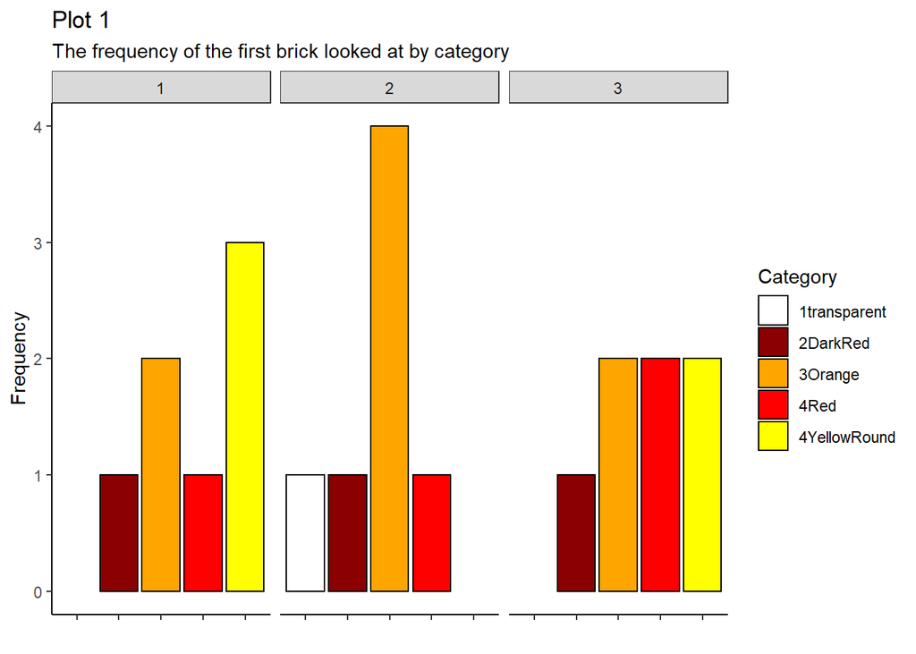

```r
# Make lists of unique ID's and blocks to enable looping over each ID and block one by one.
ID_list <- unique(data$participantID)

# Create empty 'container' to which the gathered data will be appended.
vis1 <- tibble()

# Loop over every ID
for (ID_idx in 1:length(ID_list)){

  # Get iD one by one
  ID <- ID_list[ID_idx]

  # get data from the current ID
  sub <- data %>% filter(participantID == ID)

  # Get the first fixation from each block
  sub <- sub[!duplicated(sub$block),]

  # Append first fixation for each block to the df outside the loop
  if (nrow(vis1) == 0){
    vis1 <- sub}
  else {
    vis1 <- rbind(vis1, sub)}

}

# Create summary of the data to be plotted
vis1 <- vis1 %>% group_by(block, Category) %>% summarise(
  freq = n()
)

# Create ggplot
ggplot(vis1,aes(x=Category, y = freq, fill=Category)) +

  # Place the bars next to each other and seperate by block number + choose black/whote theme
  geom_col(position="dodge", color = "black") + facet_wrap(~ block) + theme_bw() +

  # Change colors of the bars to correspond to the brick colors
  scale_fill_manual("Category", values = c(
    "1transparent" = "white",
    "2DarkRed" = "darkred",
    "3Orange" = "orange",
    "4Red" = "red",
    "4YellowRound" = "yellow")) +

  # Change layout
  theme(
    # Remove grids behind the bars
    panel.border = element_blank(),
    panel.grid.major = element_blank(),
    panel.grid.minor = element_blank(),
    axis.text.x = element_blank(),
    # Draw black line around the plot
    axis.line = element_line(colour = "black")) +

  # Add labels
  labs(title = "Plot 1", subtitle = "The frequency of the first brick looked at by category") +
  xlab("") + ylab("Frequency")
```

### (Plot 2) How many times each brick has been looked at?

Plot the count of fixations on each brick for each block. The bar is an average across participants. Errorbars indicate the standard error.

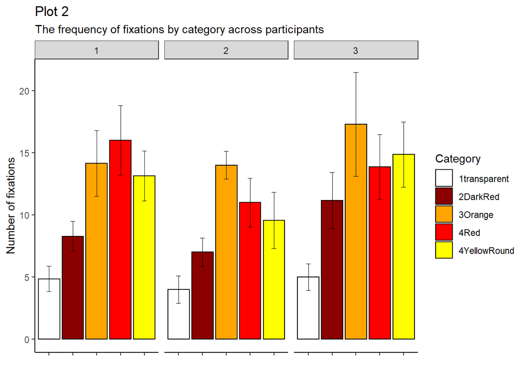

```r
# Drop rows with the categories Base, Configuration and Minibase
vis2 <-data[!(data$Category=='Base' | data$Category=='Configuration' | data$Category=='Minibase'),]

# Prepare data
vis2 <- vis2 %>%

  # get the number of fixations on each brick by participant - and change it to numeric
  group_by(participantID, block, Category) %>%
  summarise(freq = n()) %>%
  mutate(freq = as.numeric(freq)) %>%

  # Calculate the mean and se for each category in each block
  group_by(block, Category) %>%
  summarise(MEAN = mean(freq),  # calculates the mean of each group
            SE = sd(freq)/sqrt(n())) # calculates the standard error of each group


# Run the plot
ggplot(vis2, aes(x = Category, y = MEAN, fill = Category)) +
  geom_col(position="dodge", color = "black") +
  scale_fill_manual("Category", values = c(
    "1transparent" = "white",
    "2DarkRed" = "darkred",
    "3Orange" = "orange",
    "4Red" = "red",
    "4YellowRound" = "yellow")) +
  facet_wrap(~ block) +
  theme_bw() +
  geom_errorbar(aes(ymin=MEAN-SE, ymax=MEAN+SE), size=.3, width=.2, position=position_dodge(.9)) +

  # Change layout
  theme(
    # Remove grids behind the bars
    panel.border = element_blank(),
    panel.grid.major = element_blank(),
    panel.grid.minor = element_blank(),
    axis.text.x = element_blank(),
    # Draw black line around the plot
    axis.line = element_line(colour = "black")) +

  # Add labels
  labs(title = "Plot 2", subtitle = "The frequency of fixations by category across participants") +
  xlab("") + ylab("Number of fixations")
```

### (Plot 3) Total fixation duration

Plot the total fixation duration on each brick category by block. This is to comare with plot 2.

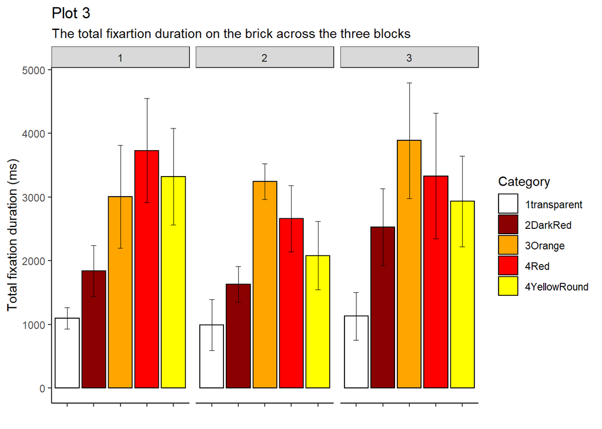

```r
# Drop rows with the categories Base, Configuration and Minibase
vis3 <-data[!(data$Category=='Base' | data$Category=='Configuration' | data$Category=='Minibase'),]

# Prepare data
vis3 <- vis3 %>%

  # get the number of fixations on each brick by participant - and change it to numeric
  group_by(participantID, block, Category) %>%
  summarise(total_duration = sum(duration_ms)) %>%
  mutate(total_duration = as.numeric(total_duration)) %>%

  # Calculate the mean and se for each category in each block
  group_by(block, Category) %>%
  summarise(MEAN = mean(total_duration),  # calculates the mean of each group
            SE = sd(total_duration)/sqrt(n())) # calculates the standard error of each group

# Run the plot
ggplot(vis3, aes(x = Category, y = MEAN, fill = Category)) +
  geom_col(position="dodge", color = "black") +
  scale_fill_manual("Category", values = c(
    "1transparent" = "white",
    "2DarkRed" = "darkred",
    "3Orange" = "orange",
    "4Red" = "red",
    "4YellowRound" = "yellow")) +
  facet_wrap(~ block) +
  theme_bw() +
  geom_errorbar(aes(ymin=MEAN-SE, ymax=MEAN+SE), size=.3, width=.2, position=position_dodge(.9)) +

  # Change layout
  theme(
    # Remove grids behind the bars
    panel.border = element_blank(),
    panel.grid.major = element_blank(),
    panel.grid.minor = element_blank(),
    axis.text.x = element_blank(),
    # Draw black line around the plot
    axis.line = element_line(colour = "black")) +

  # Add labels
  labs(title = "Plot 3", subtitle = "The total fixartion duration on the brick across the three blocks") +
  xlab("") + ylab("Total fixation duration (ms)")
```

### (Plot 4) mean fixation duration

On average, how long time do the participants spent looking at each brick?

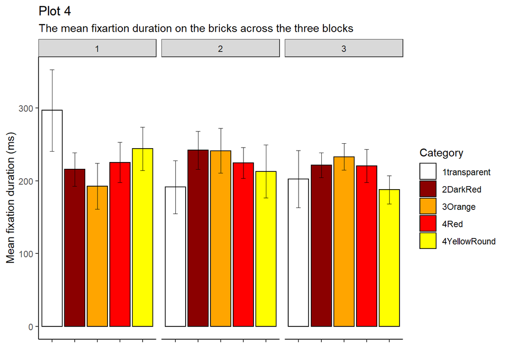

```r
# Drop rows with the categories Base, Configuration and Minibase
vis4 <-data[!(data$Category=='Base' | data$Category=='Configuration' | data$Category=='Minibase'),]

# Prepare data
vis4 <- vis4 %>%

  # get the number of fixations on each brick by participant - and change it to numeric
  group_by(participantID, block, Category) %>%
  summarise(mean_duration = mean(duration_ms)) %>%
  mutate(mean_duration = as.numeric(mean_duration)) %>%

  # Calculate the mean and se for each category in each block
  group_by(block, Category) %>%
  summarise(MEAN = mean(mean_duration),  # calculates the mean of each group
            SE = sd(mean_duration)/sqrt(n())) # calculates the standard error of each group

# Run the plot
ggplot(vis4, aes(x = Category, y = MEAN, fill = Category)) +
  geom_col(position="dodge", color = "black") +
  scale_fill_manual("Category", values = c(
    "1transparent" = "white",
    "2DarkRed" = "darkred",
    "3Orange" = "orange",
    "4Red" = "red",
    "4YellowRound" = "yellow")) +
  facet_wrap(~ block) +
  theme_bw() +
  geom_errorbar(aes(ymin=MEAN-SE, ymax=MEAN+SE), size=.3, width=.2, position=position_dodge(.9)) +

  # Change layout
  theme(
    # Remove grids behind the bars
    panel.border = element_blank(),
    panel.grid.major = element_blank(),
    panel.grid.minor = element_blank(),
    axis.text.x = element_blank(),
    # Draw black line around the plot
    axis.line = element_line(colour = "black")) +

  # Add labels
  labs(title = "Plot 4", subtitle = "The mean fixartion duration on the bricks across the three blocks") +
  xlab("") + ylab("Mean fixation duration (ms)")
```

## Visualizing interactions

We are no longer visualising fixations but 'used' meaning the interaction with the bricks

### (Plot 5) Most used bricks

Plot the count of interactions with each brick for each block. The bar is an average across participants. Errorbars indicate the standard error.

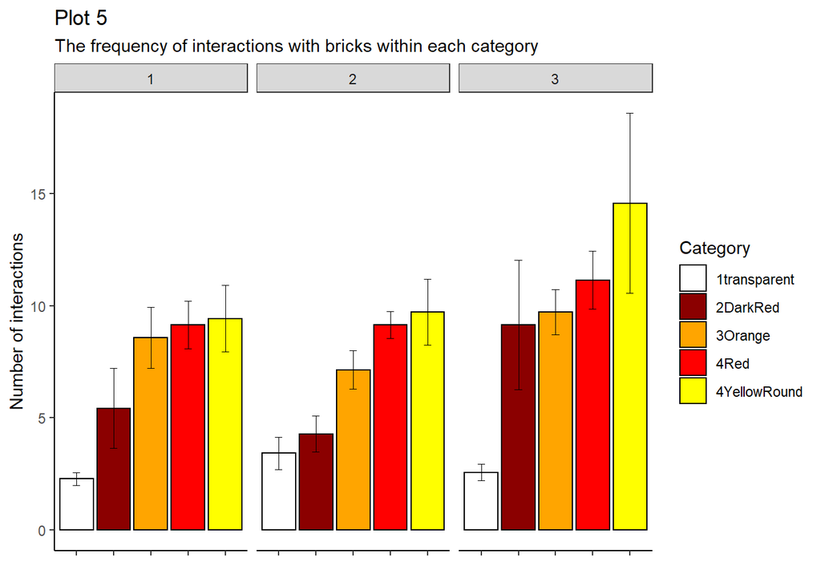

```r
# Apply the homemade function to the data.
# Now, the data only contains rows where the behavior starts with "U".
data = SubsetByLetter(dataAll, "u")

# Change variable to factors
data <- data %>% mutate(
  behavior = as.factor(behavior),
  Category = as.factor(behavioral_category),
  participantID = as.factor(participantID),
  block = as.factor(block)
)


# Drop rows with the categories Base, Configuration and Minibase
vis5 <-data[!(data$Category=='Base' | data$Category=='Configuration' | data$Category=='Minibase'),]

# Prepare data
vis5 <- vis5 %>%

  # get the number of interactions on each brick by participant - and change it to numeric
  group_by(participantID, block, Category) %>%
  summarise(freq = n()) %>%
  mutate(freq = as.numeric(freq)) %>%

  # Calculate the mean and se for each category in each block
  group_by(block, Category) %>%
  summarise(MEAN = mean(freq),  # calculates the mean of each group
            SE = sd(freq)/sqrt(n())) # calculates the standard error of each group


# Run the plot
ggplot(vis5, aes(x = Category, y = MEAN, fill = Category)) +
  geom_col(position="dodge", color = "black") +
  scale_fill_manual("Category", values = c(
    "1transparent" = "white",
    "2DarkRed" = "darkred",
    "3Orange" = "orange",
    "4Red" = "red",
    "4YellowRound" = "yellow")) +
  facet_wrap(~ block) +
  theme_bw() +
  geom_errorbar(aes(ymin=MEAN-SE, ymax=MEAN+SE), size=.3, width=.2, position=position_dodge(.9)) +

  # Change layout
  theme(
    # Remove grids behind the bars
    panel.border = element_blank(),
    panel.grid.major = element_blank(),
    panel.grid.minor = element_blank(),
    axis.text.x = element_blank(),
    # Draw black line around the plot
    axis.line = element_line(colour = "black")) +

  # Add labels
  labs(title = "Plot 5", subtitle = "The frequency of interactions with bricks within each category") +
  xlab("") + ylab("Number of interactions")
```

### (Plot 6) Total interaction duration

For how long does the participants on average interact with each brick category?

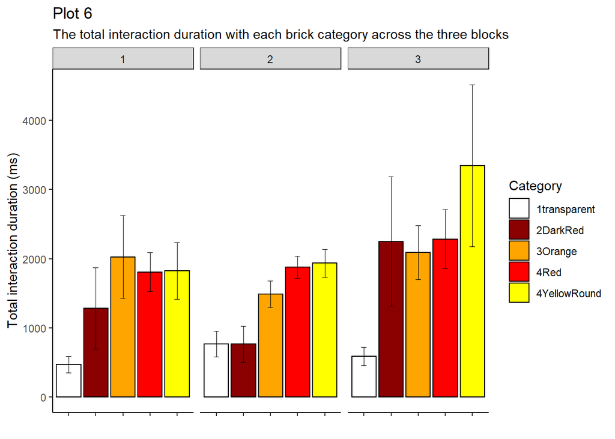

```r
# Drop rows with the categories Base, Configuration and Minibase
vis6 <-data[!(data$Category=='Base' | data$Category=='Configuration' | data$Category=='Minibase'),]

# Prepare data
vis6 <- vis6 %>%

  # get the number of fixations on each brick by participant - and change it to numeric
  group_by(participantID, block, Category) %>%
  summarise(total_duration = sum(duration_ms)) %>%
  mutate(total_duration = as.numeric(total_duration)) %>%

  # Calculate the mean and se for each category in each block
  group_by(block, Category) %>%
  summarise(MEAN = mean(total_duration),  # calculates the mean of each group
            SE = sd(total_duration)/sqrt(n())) # calculates the standard error of each group

# Run the plot
ggplot(vis6, aes(x = Category, y = MEAN, fill = Category)) +
  geom_col(position="dodge", color = "black") +
  scale_fill_manual("Category", values = c(
    "1transparent" = "white",
    "2DarkRed" = "darkred",
    "3Orange" = "orange",
    "4Red" = "red",
    "4YellowRound" = "yellow")) +
  facet_wrap(~ block) +
  theme_bw() +
  geom_errorbar(aes(ymin=MEAN-SE, ymax=MEAN+SE), size=.3, width=.2, position=position_dodge(.9)) +

  # Change layout
  theme(
    # Remove grids behind the bars
    panel.border = element_blank(),
    panel.grid.major = element_blank(),
    panel.grid.minor = element_blank(),
    axis.text.x = element_blank(),
    # Draw black line around the plot
    axis.line = element_line(colour = "black")) +

  # Add labels
  labs(title = "Plot 6", subtitle = "The total interaction duration with each brick category across the three blocks") +
  xlab("") + ylab("Total interaction duration (ms)")
```

### (Plot 7) Mean interaction time

What is the mean interaction duration on each brick category across blocks?

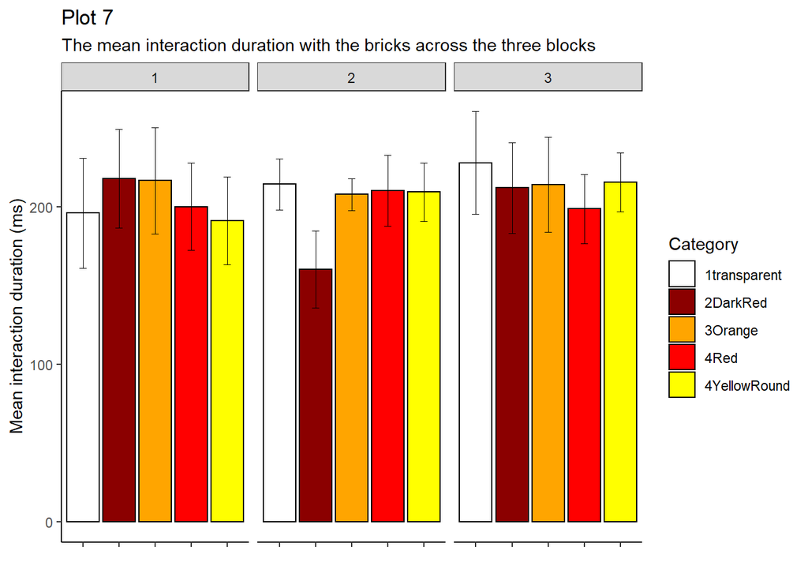

```r
# Drop rows with the categories Base, Configuration and Minibase
vis7 <-data[!(data$Category=='Base' | data$Category=='Configuration' | data$Category=='Minibase'),]

# Prepare data
vis7 <- vis7 %>%

  # get the number of fixations on each brick by participant - and change it to numeric
  group_by(participantID, block, Category) %>%
  summarise(mean_duration = mean(duration_ms)) %>%
  mutate(mean_duration = as.numeric(mean_duration)) %>%

  # Calculate the mean and se for each category in each block
  group_by(block, Category) %>%
  summarise(MEAN = mean(mean_duration),  # calculates the mean of each group
            SE = sd(mean_duration)/sqrt(n())) # calculates the standard error of each group

# Run the plot
ggplot(vis7, aes(x = Category, y = MEAN, fill = Category)) +
  geom_col(position="dodge", color = "black") +
  scale_fill_manual("Category", values = c(
    "1transparent" = "white",
    "2DarkRed" = "darkred",
    "3Orange" = "orange",
    "4Red" = "red",
    "4YellowRound" = "yellow")) +
  facet_wrap(~ block) +
  theme_bw() +
  geom_errorbar(aes(ymin=MEAN-SE, ymax=MEAN+SE), size=.3, width=.2, position=position_dodge(.9)) +

  # Change layout
  theme(
    # Remove grids behind the bars
    panel.border = element_blank(),
    panel.grid.major = element_blank(),
    panel.grid.minor = element_blank(),
    axis.text.x = element_blank(),
    # Draw black line around the plot
    axis.line = element_line(colour = "black")) +

  # Add labels
  labs(title = "Plot 7", subtitle = "The mean interaction duration with the bricks across the three blocks") +
  xlab("") + ylab("Mean interaction duration (ms)")
```

## Modelling

**The hypothesis** In the beginning, the kids will look more at the 4 yellow round brick and the transparent – because they attract attention when building a car. Afterwards they are used to them and will switch to look more at the other categories. - Add predictor with the number of bricks in the same category.

I run the following model > total_duration ~ 1 + bricks + Category + Category:block + (1|participantID)

The total duration is predicted from the number of items in the given category, the category as well as an interaction effect between category and block. The number of items in each category might influence the fixation duration. We are not interested in this potential effect but want to account for it. The category might also influence the fixation duration. Finally, there might be an interaction effect between the block and the category - and this is the effect we are interested in. It could be that the total fixation duration in one catgeory decreases over across blocks while it increases for another category.

```r
# Apply the function to the data. Now, the data only contains rows where the behavior starts with "l".
data = SubsetByLetter(dataAll)

# Change variable to factors
data <- data %>% mutate(
  behavior = as.factor(behavior),
  Category = as.factor(behavioral_category),
  participantID = as.factor(participantID),
  block = as.integer(block)
)

# Drop rows with the categories Base, Configuration and Minibase
data <-data[!(data$Category=='Base' | data$Category=='Configuration' | data$Category=='Minibase'),]

# Prepare data
data <- data %>%

  # get the number of fixations on each brick by participant - and change it to numeric
  group_by(participantID, block, Category) %>%
  summarise(total_duration = sum(duration_ms)) %>%
  mutate(total_duration = as.numeric(total_duration))

# Extract number of bricks in each category and change to integer
data$bricks <- stringr::str_extract(data$Category, "^.{1}")
data$bricks <- as.integer(data$bricks)

# Run model
model <- lmer(total_duration ~ 1 + bricks + Category + Category:block + (1|participantID), data = data)
```

```
## fixed-effect model matrix is rank deficient so dropping 1 column / coefficient
```

```r
summary(model)
```

```
## Linear mixed model fit by REML. t-tests use Satterthwaite's method [
## lmerModLmerTest]
## Formula: total_duration ~ 1 + bricks + Category + Category:block + (1 |
##     participantID)
##    Data: data
##
## REML criterion at convergence: 1661
##
## Scaled residuals:
##     Min      1Q  Median      3Q     Max
## -2.3113 -0.5511 -0.0100  0.5080  2.9533
##
## Random effects:
##  Groups        Name        Variance Std.Dev.
##  participantID (Intercept)  955669   977.6
##  Residual                  1735760  1317.5
## Number of obs: 104, groups:  participantID, 7
##
## Fixed effects:
##                            Estimate Std. Error      df t value Pr(>|t|)
## (Intercept)                  334.05    1108.79   88.53   0.301   0.7639
## bricks                       707.91     358.57   88.01   1.974   0.0515 .
## Category2DarkRed            -411.71     958.64   88.04  -0.429   0.6686
## Category3Orange               38.74     948.70   88.01   0.041   0.9675
## Category4Red                 477.14    1075.72   88.01   0.444   0.6585
## Category1transparent:block    14.93     352.11   88.01   0.042   0.9663
## Category2DarkRed:block       323.41     366.95   88.12   0.881   0.3805
## Category3Orange:block        441.16     352.11   88.01   1.253   0.2136
## Category4Red:block          -201.10     352.11   88.01  -0.571   0.5694
## Category4YellowRound:block  -193.80     352.11   88.01  -0.550   0.5834
## ---
## Signif. codes:  0 '***' 0.001 '**' 0.01 '*' 0.05 '.' 0.1 ' ' 1
##
## Correlation of Fixed Effects:
##             (Intr) bricks Ctg2DR Ctgr3O Ctgr4R Ctgr1: Ct2DR: Ctg3O: Ctg4R:
## bricks      -0.808
## Ctgry2DrkRd -0.423  0.187
## Catgry3Orng -0.122 -0.189  0.283
## Category4Rd  0.162 -0.500  0.187  0.378
## Ctgry1trns: -0.847  0.655  0.490  0.247  0.000
## Ctgry2DrkR:  0.000  0.000 -0.745  0.000  0.000  0.000
## Ctgry3Orng:  0.000  0.000  0.000 -0.742  0.000  0.000  0.000
## Ctgry4Rd:bl  0.000  0.000  0.000  0.000 -0.655  0.000  0.000  0.000
## Ctgry4YllR:  0.212 -0.655  0.245  0.495  0.655  0.000  0.000  0.000  0.000
## fit warnings:
## fixed-effect model matrix is rank deficient so dropping 1 column / coefficient
```